# Application Processing Efficiency Analysis

### Cats

Reduce number of predictors

```r
appsandcards <- cat.appsandcards[,c("GEOID","efficient")]

all.geo <- appsandcards %>%
  group_by(GEOID) %>%
  summarise(efficient = sum(efficient)/n())
all.geo <- merge(all.geo,
                 census,
                 by.x="GEOID",
                 by.y="GEO.id2_educ",
                 all.x=TRUE)
all.geo <- all.geo[complete.cases(all.geo),]

x <- model.matrix(efficient ~., data = all.geo)
x <- x[,-1]

cvfit <- cv.glmnet(x, all.geo$efficient, type.measure = 'mse', nfolds=5, alpha=.5)
c <- coef(cvfit, s='lambda.min', exact=TRUE)
inds <- which(c!=0)
vars <- data.frame(var = row.names(c)[inds],
                   value = c[inds])
vars <- vars[which(!vars$var %in% c("(Intercept)","GEOID")),]
vars <- vars[order(abs(vars$value), decreasing = TRUE),]

m <- as.formula(paste("efficient ~",paste0(vars$var,collapse = "+")))
summary(lm(m, data=all.geo))
```

```
##
## Call:
## lm(formula = m, data = all.geo)
##
## Residuals:
##      Min       1Q   Median       3Q      Max
## -0.76098 -0.40741  0.06659  0.34341  0.72746
##
## Coefficients:
##                     Estimate Std. Error t value Pr(>|t|)
## (Intercept)         0.049024   0.335355   0.146 0.883860
## HC02_EST_VC06_educ -0.011807   0.003525  -3.349 0.000901 ***
## HC02_EST_VC04_educ -0.006752   0.006200  -1.089 0.276901
## HC02_EST_VC19_comp  0.003817   0.002059   1.854 0.064626 .
## HC02_EST_VC22_comp  0.016654   0.010797   1.542 0.123902
## HC02_EST_VC19_educ  0.005244   0.003080   1.702 0.089608 .
## HC02_EST_VC07_educ  0.006093   0.003161   1.928 0.054725 .
## HC02_EST_VC06_comp -0.005969   0.005812  -1.027 0.305149
## HC02_EST_VC09_educ  0.001926   0.002695   0.715 0.475364
## ---
## Signif. codes:  0 '***' 0.001 '**' 0.01 '*' 0.05 '.' 0.1 ' ' 1
##
## Residual standard error: 0.4048 on 341 degrees of freedom
## Multiple R-squared:  0.1001, Adjusted R-squared:  0.079
## F-statistic: 4.742 on 8 and 341 DF,  p-value: 1.558e-05
```

```r
all.geo.spatial <-
  sp::merge(x = pa_nj, y = all.geo, by = "GEOID", all.x=FALSE, all.y=TRUE)
all.geo.spatial <- all.geo.spatial[all.geo.spatial$COUNTYFP=="101",]

# calculate distance to nearest PAWS location

# PAWS Adoption locations taken from their website, and latlong obtained via https://gps-coordinates.org/
# PAC lat = 39.952030; Long = -75.143410
# NE lat =  40.084923, long = -75.036904
# Kawaii kitty Cafe Lat = 39.93867, long = -75.1496
# Petsmart Oregon Ave Lat = 39.917239, Lon = -75.187238
# Petsmart Broad & Washington Lat = 39.937967, Lon = -75.167576
# Grays Ferry Lat = 39.938748 Lon = -75.192532

for (i in 1:nrow(all.geo.spatial)){
  all.geo.spatial$PAC.dist[i] <-  distm(c(as.numeric(all.geo.spatial$INTPTLON[i]),as.numeric(all.geo.spatial$INTPTLAT[i])),c(-75.143410, 39.952030), fun=distGeo)
  all.geo.spatial$NE.dist[i] <-  distm(c(as.numeric(all.geo.spatial$INTPTLON[i]),as.numeric(all.geo.spatial$INTPTLAT[i])),c(-75.036904, 40.084923), fun=distGeo)
  all.geo.spatial$KK.dist[i] <-  distm(c(as.numeric(all.geo.spatial$INTPTLON[i]),as.numeric(all.geo.spatial$INTPTLAT[i])),c(-75.1496, 39.93867), fun=distGeo)
  all.geo.spatial$PS.dist[i] <-  distm(c(as.numeric(all.geo.spatial$INTPTLON[i]),as.numeric(all.geo.spatial$INTPTLAT[i])),c(-75.187238, 39.917239), fun=distGeo)
  all.geo.spatial$PSO.dist[i] <-  distm(c(as.numeric(all.geo.spatial$INTPTLON[i]),as.numeric(all.geo.spatial$INTPTLAT[i])),c(-75.187238, 39.917239), fun=distGeo)
  all.geo.spatial$PSO.dist[i] <-  distm(c(as.numeric(all.geo.spatial$INTPTLON[i]),as.numeric(all.geo.spatial$INTPTLAT[i])),c(-75.167576, 39.937967), fun=distGeo)
  all.geo.spatial$GF.dist[i] <-  distm(c(as.numeric(all.geo.spatial$INTPTLON[i]),as.numeric(all.geo.spatial$INTPTLAT[i])),c(-75.192532, 39.938748), fun=distGeo)
  all.geo.spatial$shortest.distance[i] <- min(all.geo.spatial$PAC.dist[i],
                                              all.geo.spatial$NE.dist[i],
                                              all.geo.spatial$KK.dist[i],
                                              all.geo.spatial$PS.dist[i],
                                              all.geo.spatial$PSO.dist[i],
                                              all.geo.spatial$GF.dist[i])
  }

# compute model

m <- as.formula(paste("efficient ~", paste0(vars$var, collapse="+"), "+ shortest.distance"))
model <- lm(m, data=all.geo.spatial)
summary(model)
```

```
##
## Call:
## lm(formula = m, data = all.geo.spatial)
##
## Residuals:
##      Min       1Q   Median       3Q      Max
## -0.79773 -0.25854  0.02187  0.32625  0.63682
##
## Coefficients:
##                      Estimate Std. Error t value Pr(>|t|)
## (Intercept)         4.438e-01  3.799e-01   1.168  0.24403
## HC02_EST_VC06_educ -1.160e-02  4.027e-03  -2.880  0.00437 **
## HC02_EST_VC04_educ -5.132e-03  6.714e-03  -0.764  0.44545
## HC02_EST_VC19_comp  3.618e-03  2.730e-03   1.325  0.18653
## HC02_EST_VC22_comp  7.444e-03  1.174e-02   0.634  0.52689
## HC02_EST_VC19_educ  1.104e-03  3.225e-03   0.342  0.73236
## HC02_EST_VC07_educ  5.468e-03  3.616e-03   1.512  0.13196
## HC02_EST_VC06_comp  3.869e-04  6.589e-03   0.059  0.95323
## HC02_EST_VC09_educ  1.966e-03  2.939e-03   0.669  0.50422
## shortest.distance  -3.077e-06  8.086e-06  -0.381  0.70390
## ---
## Signif. codes:  0 '***' 0.001 '**' 0.01 '*' 0.05 '.' 0.1 ' ' 1
##
## Residual standard error: 0.3713 on 217 degrees of freedom
## Multiple R-squared:  0.1057, Adjusted R-squared:  0.06865
## F-statistic: 2.851 on 9 and 217 DF,  p-value: 0.003398
```

```
## Variable "map.resids" contains positive and negative values, so midpoint is set to 0. Set midpoint = NA to show the full spectrum of the color palette.
```

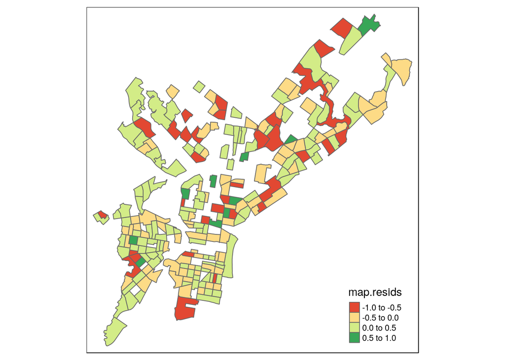

```r
resids<-residuals(model)
all.geo.spatial$map.resids <- resids
qtm(all.geo.spatial, fill = "map.resids")
```

HC02_EST_VC06_educ is the only significant variable.

```r
library("spgwr")
GWRbandwidth <- gwr.sel(m, data=all.geo.spatial,adapt=T)
```

```
## Adaptive q: 0.381966 CV score: 33.36831
## Adaptive q: 0.618034 CV score: 32.93135
## Adaptive q: 0.763932 CV score: 32.83302
## Adaptive q: 0.800322 CV score: 32.81753
## Adaptive q: 0.8765922 CV score: 32.78267
## Adaptive q: 0.9237298 CV score: 32.76519
## Adaptive q: 0.9528624 CV score: 32.7523
## Adaptive q: 0.9708674 CV score: 32.73985
## Adaptive q: 0.981995 CV score: 32.7329
## Adaptive q: 0.9888723 CV score: 32.72927
## Adaptive q: 0.9931227 CV score: 32.72134
## Adaptive q: 0.9957496 CV score: 32.71676
## Adaptive q: 0.9973731 CV score: 32.71035
## Adaptive q: 0.9983765 CV score: 32.70677
## Adaptive q: 0.9989966 CV score: 32.70468
## Adaptive q: 0.9993799 CV score: 32.70343
## Adaptive q: 0.9996167 CV score: 32.70268
## Adaptive q: 0.9997631 CV score: 32.70222
## Adaptive q: 0.9998536 CV score: 32.70194
## Adaptive q: 0.9999095 CV score: 32.70176
## Adaptive q: 0.9999502 CV score: 32.70164
## Adaptive q: 0.9999502 CV score: 32.70164
```

```r
gwr.model = gwr(m, data=all.geo.spatial,
                adapt=GWRbandwidth, hatmatrix=TRUE, se.fit=TRUE)

gwr.model
```

```
## Call:
## gwr(formula = m, data = all.geo.spatial, adapt = GWRbandwidth,
##     hatmatrix = TRUE, se.fit = TRUE)
## Kernel function: gwr.Gauss
## Adaptive quantile: 0.9999502 (about 226 of 227 data points)
## Summary of GWR coefficient estimates at data points:
##                           Min.     1st Qu.      Median     3rd Qu.
## X.Intercept.        4.0548e-01  4.1459e-01  4.2482e-01  4.4307e-01
## HC02_EST_VC06_educ -1.2451e-02 -1.2124e-02 -1.1383e-02 -1.1164e-02
## HC02_EST_VC04_educ -5.7527e-03 -5.2792e-03 -5.0654e-03 -4.8888e-03
## HC02_EST_VC19_comp  3.4317e-03  3.4705e-03  3.5432e-03  3.6098e-03
## HC02_EST_VC22_comp  6.7652e-03  7.4511e-03  7.8081e-03  8.0482e-03
## HC02_EST_VC19_educ  8.6983e-04  1.1710e-03  1.3022e-03  1.4196e-03
## HC02_EST_VC07_educ  5.2127e-03  5.3052e-03  5.3537e-03  5.3988e-03
## HC02_EST_VC06_comp -6.4792e-05  1.4486e-04  5.0663e-04  1.0801e-03
## HC02_EST_VC09_educ  1.8675e-03  1.9432e-03  1.9916e-03  2.0384e-03
## shortest.distance  -4.0110e-06 -3.5890e-06 -3.3164e-06 -3.0892e-06
##                           Max.  Global
## X.Intercept.        4.6521e-01  0.4438
## HC02_EST_VC06_educ -1.1002e-02 -0.0116
## HC02_EST_VC04_educ -4.4517e-03 -0.0051
## HC02_EST_VC19_comp  3.6569e-03  0.0036
## HC02_EST_VC22_comp  8.8589e-03  0.0074
## HC02_EST_VC19_educ  1.5941e-03  0.0011
## HC02_EST_VC07_educ  5.5115e-03  0.0055
## HC02_EST_VC06_comp  1.1688e-03  0.0004
## HC02_EST_VC09_educ  2.2048e-03  0.0020
## shortest.distance  -2.8795e-06  0.0000
## Number of data points: 227
## Effective number of parameters (residual: 2traceS - traceS'S): 11.64391
## Effective degrees of freedom (residual: 2traceS - traceS'S): 215.3561
## Sigma (residual: 2traceS - traceS'S): 0.371519
## Effective number of parameters (model: traceS): 10.85505
## Effective degrees of freedom (model: traceS): 216.1449
## Sigma (model: traceS): 0.3708404
## Sigma (ML): 0.3618651
## AICc (GWR p. 61, eq 2.33; p. 96, eq. 4.21): 207.8478
## AIC (GWR p. 96, eq. 4.22): 193.5695
## Residual sum of squares: 29.72482
## Quasi-global R2: 0.1112985
```

```r
results <-as.data.frame(gwr.model$SDF)
names(results)
```

```
##  [1] "sum.w"                     "X.Intercept."
##  [3] "HC02_EST_VC06_educ"        "HC02_EST_VC04_educ"
##  [5] "HC02_EST_VC19_comp"        "HC02_EST_VC22_comp"
##  [7] "HC02_EST_VC19_educ"        "HC02_EST_VC07_educ"
##  [9] "HC02_EST_VC06_comp"        "HC02_EST_VC09_educ"
## [11] "shortest.distance"         "X.Intercept._se"
## [13] "HC02_EST_VC06_educ_se"     "HC02_EST_VC04_educ_se"
## [15] "HC02_EST_VC19_comp_se"     "HC02_EST_VC22_comp_se"
## [17] "HC02_EST_VC19_educ_se"     "HC02_EST_VC07_educ_se"
## [19] "HC02_EST_VC06_comp_se"     "HC02_EST_VC09_educ_se"
## [21] "shortest.distance_se"      "gwr.e"
## [23] "pred"                      "pred.se"
## [25] "localR2"                   "X.Intercept._se_EDF"
## [27] "HC02_EST_VC06_educ_se_EDF" "HC02_EST_VC04_educ_se_EDF"
## [29] "HC02_EST_VC19_comp_se_EDF" "HC02_EST_VC22_comp_se_EDF"
## [31] "HC02_EST_VC19_educ_se_EDF" "HC02_EST_VC07_educ_se_EDF"
## [33] "HC02_EST_VC06_comp_se_EDF" "HC02_EST_VC09_educ_se_EDF"
## [35] "shortest.distance_se_EDF"  "pred.se.1"
```

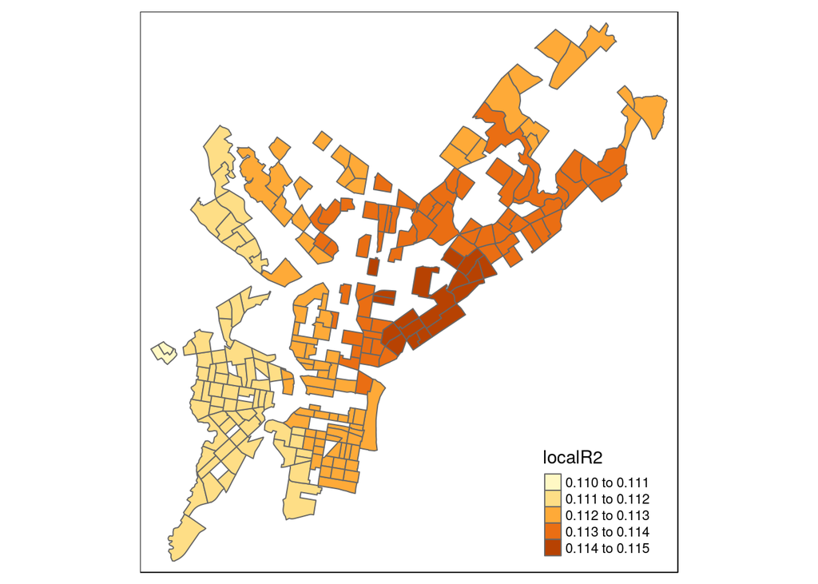

```r
gwr.map <- cbind(all.geo.spatial, as.matrix(results))
qtm(gwr.map, fill = "localR2")
```

```r
lm.coeffs <- as.data.frame(summary(model)$coefficients)

var = 'HC02_EST_VC06_educ'
print(as.character(census.descr$descr[which(census.descr$select.vars==var)]))
```

```
## [1] "Percent; Estimate; Elementary: grade 5 to grade 8"
```

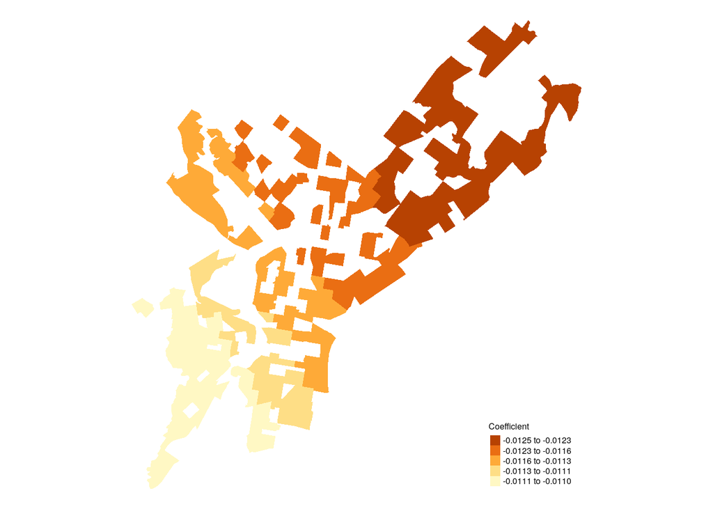

```r
tm_shape(gwr.map) + tm_fill(paste0(var,".1"), n = 5, style = "quantile", title = "Coefficient") + tm_layout(frame = FALSE, legend.text.size = 0.5, legend.title.size = 0.6)
```

```r
# saved as rplot03.png
```

The variable Percent; Estimate; Elementary: grade 5 to grade 8 is a significant predictor of proportion of applications that are processed efficiently (10 days or less). Specifically, the higher the percentage of kids enrolled in grades 5-8, the lower the proportion of efficient applications. This effect seems to be more noticeable in the northeast.

```r
lm.coeffs <- as.data.frame(summary(model)$coefficients)

var = 'HC02_EST_VC06_educ'
print(as.character(census.descr$descr[which(census.descr$select.vars==var)]))
```

```
## [1] "Percent; Estimate; Elementary: grade 5 to grade 8"
```

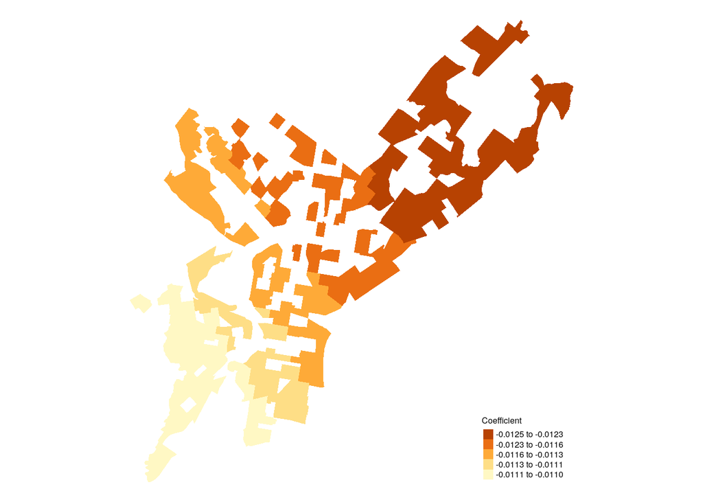

```r
tm_shape(gwr.map) + tm_fill(paste0(var,".1"), n = 5, style = "quantile", title = "Coefficient") + tm_layout(frame = FALSE, legend.text.size = 0.5, legend.title.size = 0.6)
```

```r
# saved as rplot03.png
```